# Panel Data and Fixed Effects

EC 325: Econometrics

Prof. Caraher

Colby College

2026-04-09

## Where We Are

- The **Fundamental Problem of Causal Inference**
  - Cannot observe both the treated and untreated outcome for unit $i$ – no multiverse!
  - Need to control for **Selection Bias** to ensure **apples-to-apples** comparisons
- Best method: the “gold standard” of the **RCT**
  - Random assignment ensures comparable treatment and control groups
- Next best alternative: **multivariate OLS**
  - Control directly for omitted variables which may cause selection bias
- We can control for what we can observe… but what about **unobservable** confounders? Ability, motivation, culture, history?

Today: a new data structure — **panel data** — that lets us control for (certain) unobservables.

## Cross-Sectional Data

Most datasets we’ve looked at so far have been **cross-sectional**: units observed at a single point in time.

- Housing prices in Ames, Iowa in 2010
- Wages and education data from the CPS
- Health outcomes in the Oregon Health Insurance Experiment
- Women’s labor force participation (`mroz`)

## What We Can Do with Cross-Sectional Data

With a snapshot from a single point in time, we can:

- **Describe a population**: averages, medians, distributions
- **Identify correlations**: do two variables move together?
- **Control for observable confounders**: multivariate OLS, holding other measured factors constant

But there’s a big limitation…

## What Cross-Sectional Data Struggles With

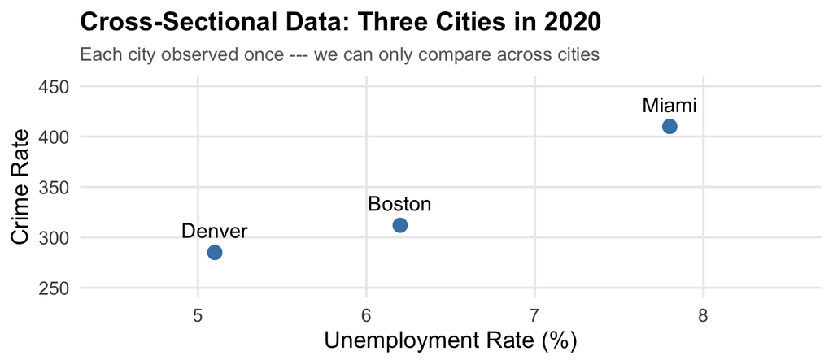

Figure 1

Miami has high unemployment **and** high crime. But is that because unemployment *causes* crime, or because Miami differs in many unobserved ways (geography, culture, history)?

We can’t control for what we can’t measure!

## Panel Data

This is in contrast to **panel data**: the same units observed at *multiple points in time*.

- NBA players observed across multiple seasons
- Employment and minimum wages in states across multiple quarters
- Pre-period and post-period data in an experiment
- Stock prices for multiple companies tracked daily for a year

| Example | Unit ($i$) | Time ($t$) |
| --- | --- | --- |
| Workers tracked annually | Person | Year |
| States observed quarterly | State | Quarter |
| Firms reported monthly | Firm | Month |
| Countries measured yearly | Country | Year |

## What If We Followed Cities Over Time?

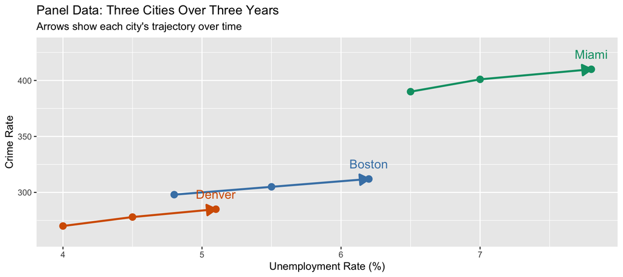

Figure 2

Now we can ask: when unemployment rises **within a given city**, does crime rise too?

## Benefits of Panel Data

1. **Controlling for Unobserved Heterogeneity**
   - Observing units over time lets us control for all *time-invariant* characteristics — both **observed and unobserved**!
   - Geography, genetics, a firm’s core industry, “culture” — as long as they’re stable, panel methods can remove their influence
   - This is the **big one** and the focus of today’s lecture

## Benefits of Panel Data (cont.)

2. **Analyzing Dynamics of Change**
   - We can study how variables change over time and why
   - Analyze the impact of events, policies, or treatments by comparing units before and after
   - Examine lags and leads (does a change in $x$ today affect $y$ tomorrow?)
3. **Increased Statistical Power**
   - Pooling data across units *and* time increases total sample size ($N \times T$)
   - More data $\rightarrow$ more precise estimates (smaller standard errors)

## The Key Insight

Panel data lets us control for **all time-invariant characteristics** of each unit — whether observed or unobserved — by using only **within-unit** variation.

- **Between** variation: comparing *different* cities to each other (confounded by all ways cities differ)
- **Within** variation: comparing *each city to itself* over time (city-level confounders cancel out)

The question shifts from “do cities with more unemployment have more crime?” to “when unemployment rises *within a city*, does crime rise too?”

## The Fixed Effects Model

We formalize this with the **fixed effects model**:

$$y_{it} = \beta_0 + \beta_1 x_{it} + a_i + \mu_{it}$$

- $y_{it}$: outcome for unit $i$ at time $t$
- $x_{it}$: explanatory variable (varies across units **and** time)
- $a_i$: **unit fixed effect** — captures all time-invariant characteristics of unit $i$
- $\mu_{it}$: idiosyncratic error (the leftover)

## What Does $a_i$ Capture?

The unit fixed effect $a_i$ absorbs **everything** about unit $i$ that doesn’t change over time:

- A city’s geographic location
- A city’s historical legacy and founding conditions
- Stable institutional features (legal system, political structure)
- Baseline demographics (to the extent they’re stable)
- Measurement differences (how crime is recorded)
- “Culture” and other hard-to-measure factors

We don’t need to **observe** these things. We don’t need to **measure** them. We just need them to be **stable** over the time periods we observe.

## How Does It Work? The Within Transformation (1/3)

We can’t observe $a_i$ directly. But we can **eliminate** it.

**Step 1:** For each unit $i$, compute the time average of every variable:

$$\bar{y}_i = \beta_0 + \beta_1 \bar{x}_i + a_i + \bar{\mu}_i$$

## How Does It Work? The Within Transformation (2/3)

**Step 2:** Subtract the time-average equation from the original:

$$\begin{align}
y_{it} - \bar{y}_i &= (\beta_0 - \bar{\beta}_0) + \beta_1(x_{it} - \bar{x}_i) + (a_i - \bar{a}_i) + (\mu_{it} - \bar{\mu}_i)
\end{align}$$

What happened?

- $a_i - \bar{a}_i = a_i - a_i = 0$ — **the fixed effect drops out!** Since $a_i$ is constant over time, its time average is just itself
- $\beta_0 - \bar{\beta}_0 = 0$ — the intercept also drops out . . .

We’re left with only **demeaned** variables:

$$\ddot{y}_{it} = \beta_1 \ddot{x}_{it} + \ddot{\mu}_{it}$$

where $\ddot{y}_{it} = y_{it} - \bar{y}_i$ (deviations from each unit’s own average), and so on.

## How Does It Work? The Within Transformation (3/3)

**Why “within” transformation?**

After demeaning, all cross-sectional differences between units are gone. The only variation left is how each unit **differs from its own average** over time.

$\beta_1$ is identified purely from **within-unit changes**.

Let’s see this in action with a concrete example…

## Within Transformation: A Small Example (1/3)

Suppose we have 3 cities observed over 2 years. Here’s our **raw data**:

```r
example_df <- tibble(
  city = rep(c("A", "B", "C"), each = 2),
  year = rep(c(1, 2), times = 3),
  unem = c(5, 7, 3, 5, 8, 6),
  crime = c(30, 34, 20, 26, 40, 38)
)
example_df
```

```
# A tibble: 6 × 4
  city   year  unem crime
  <chr> <dbl> <dbl> <dbl>
1 A         1     5    30
2 A         2     7    34
3 B         1     3    20
4 B         2     5    26
5 C         1     8    40
6 C         2     6    38
```

City A: unemployment went up (5 to 7), crime went up (30 to 34). City C: unemployment went *down* (8 to 6), crime went *down* (40 to 38). That’s the within-unit variation we want to use.

## Within Transformation: A Small Example (2/3)

**Step 1:** Compute each city’s time average, then subtract:

```r
example_df <- example_df |>
  group_by(city) |>
  mutate(
    mean_unem = mean(unem),
    mean_crime = mean(crime),
    unem_demean = unem - mean_unem,
    crime_demean = crime - mean_crime
  ) |>
  ungroup()

example_df |> select(city, year, unem, mean_unem, unem_demean, crime, mean_crime, crime_demean)
```

```
# A tibble: 6 × 8
  city   year  unem mean_unem unem_demean crime mean_crime crime_demean
  <chr> <dbl> <dbl>     <dbl>       <dbl> <dbl>      <dbl>        <dbl>
1 A         1     5         6          -1    30         32           -2
2 A         2     7         6           1    34         32            2
3 B         1     3         4          -1    20         23           -3
4 B         2     5         4           1    26         23            3
5 C         1     8         7           1    40         39            1
6 C         2     6         7          -1    38         39           -1
```

Notice: the **demeaned** values only reflect how each city differs from **its own** average — all level differences between cities are gone.

## Within Transformation: A Small Example (3/3)

**Step 2:** Regress the demeaned variables:

```r
summary(lm(crime_demean ~ unem_demean, data = example_df))
```

```
Call:
lm(formula = crime_demean ~ unem_demean, data = example_df)

Residuals:
         1          2          3          4          5          6
 4.532e-17 -6.063e-16 -1.000e+00  1.000e+00 -1.000e+00  1.000e+00

Coefficients:
              Estimate Std. Error t value Pr(>|t|)
(Intercept) -8.471e-33  4.082e-01   0.000  1.00000
unem_demean  2.000e+00  4.082e-01   4.899  0.00805 **
---
Signif. codes:  0 '***' 0.001 '**' 0.01 '*' 0.05 '.' 0.1 ' ' 1

Residual standard error: 1 on 4 degrees of freedom
Multiple R-squared:  0.8571,    Adjusted R-squared:  0.8214
F-statistic:    24 on 1 and 4 DF,  p-value: 0.00805
```

Now compare to a regression using only *between* variation:

```r
summary(lm(crime ~ unem, data = example_df) |> coef())
```

```
   Min. 1st Qu.  Median    Mean 3rd Qu.    Max.
  3.957   5.196   6.435   6.435   7.674   8.913
```

Whats the difference?

## Going Further: Time Fixed Effects

- We removed unobserved, **unit-specific** confounders by demeaning by **unit-specific across-time averages**. But what about shocks that hit **all** cities in a given year (e.g., a recession, a national policy change)?
- These are called **time-fixed effects**

We can go a step further: take our **unit-demeaned** data and demean it again — but now subtracting off **year-specific across-unit averages**:

```r
example_df <- example_df |>
  group_by(year) |>
  mutate(
    yr_mean_unem_dm = mean(unem_demean),
    yr_mean_crime_dm = mean(crime_demean),
    unem_dm2 = unem_demean - yr_mean_unem_dm,
    crime_dm2 = crime_demean - yr_mean_crime_dm
  ) |>
  ungroup()

example_df |> select(city, year, unem_demean, yr_mean_unem_dm, unem_dm2, crime_demean, yr_mean_crime_dm, crime_dm2)
```

```
# A tibble: 6 × 8
  city   year unem_demean yr_mean_unem_dm unem_dm2 crime_demean yr_mean_crime_dm
  <chr> <dbl>       <dbl>           <dbl>    <dbl>        <dbl>            <dbl>
1 A         1          -1          -0.333   -0.667           -2            -1.33
2 A         2           1           0.333    0.667            2             1.33
3 B         1          -1          -0.333   -0.667           -3            -1.33
4 B         2           1           0.333    0.667            3             1.33
5 C         1           1          -0.333    1.33             1            -1.33
6 C         2          -1           0.333   -1.33            -1             1.33
# ℹ 1 more variable: crime_dm2 <dbl>
```

## Time Fixed Effects: The Result

Now regress the **doubly-demeaned** variables (no intercept needed):

```r
lm(crime_dm2 ~ 0 + unem_dm2, data = example_df) |> coef()
```

```
unem_dm2
    1.75
```

Sequential demeaning — first by unit, then by time — adds **both** unit and time fixed effects. The first demeaning removes time-invariant unit confounders; the second removes unit-invariant time shocks.

## Equivalently: Dummy Variable Regression

Instead of manually demeaning, we can estimate the same model using **dummy variable regression**:

$$y_{it} = \beta_0 + \beta_1 x_{it} + a_i + \tau_t + \mu_{it}$$

Include a **dummy variable for each unit** $i$ (minus one omitted category) and a **dummy variable for each time** $t$ (minus one omitted period).

- This produces the **same** $\hat{\beta}_1$ as the within transformation
- But also gives us estimates of each unit’s and time period’s dummy coefficient
- Don’t forget the *dummy variable trap*!

In R, we can use `factor()` to automatically create dummies, or — much more efficiently — use `feols()` from `fixest`.

**A Variation You May See**

Some implementations **drop the intercept** and include a dummy for **every** unit (no omitted category). This yields a different $\hat{\beta}_0$ interpretation (each dummy captures the unit’s own intercept), but $\hat{\beta}_1$ is **identical** either way.

## Example: Unemployment and Crime

The `crime2` dataset: **46 cities** observed in **1982 and 1987**.

Let’s start with a **cross-sectional** regression using just 1987:

```r
reg_cross <- lm(crmrte ~ unem, data = filter(crime_data, year == 87))
coef(reg_cross)
```

```
(Intercept)        unem
 128.378121   -4.161134
```

The coefficient on `unem` is **negative**: higher unemployment $\rightarrow$ *less* crime?

This makes no intuitive sense. Almost certainly **OVB** — cities with low unemployment also have other “good” characteristics (wealth, strong institutions) that reduce crime.

## Now Use the Panel: Add Fixed Effects

```r
reg_fe <- feols(crmrte ~ unem | city_id + d87, data = crime_data)
coef(reg_fe)
```

```
 unem
2.218
```

Now the coefficient is **positive**: when unemployment rises *within a city*, crime rises too.

Fixed effects removed the bias from unobserved city characteristics, revealing the true positive relationship between unemployment and crime.

## Side-by-Side Results

```r
modelsummary(list("Cross-Section" = reg_cross,
                  "Fixed Effects" = reg_fe),
             gof_map = c("adj.r.squared", "nobs"),
             add_rows = tribble(
                 ~term, ~`Cross-Section`, ~`Fixed Effects`,
                 "City FE", "No", "Yes",
                 "Year FE", "No", "Yes"
             ))
```

|  | Cross-Section | Fixed Effects |
| --- | --- | --- |
| (Intercept) | 128.378 |  |
|  | (20.757) |  |
| unem | -4.161 | 2.218 |
|  | (3.416) | (0.878) |
| R2 Adj. | 0.011 | 0.774 |
| Num.Obs. | 46 | 92 |
| City FE | No | Yes |
| Year FE | No | Yes |

Notice the bottom of the table: researchers report which fixed effects are included as “Yes/No” rows rather than reporting every dummy coefficient.

## Using `feols()` in Practice

The `feols()` function from `fixest` puts fixed effects after a vertical bar `|`:

```r
feols(y ~ x1 + x2 | unit + time, data = mydata)
```

**Left of `|`:** standard regression formula — variables you want coefficients for.

**Right of `|`:** fixed effects (absorbed) — dummies created automatically, coefficients **not** reported.

This is equivalent to including a dummy for every unit and time period, but `feols()` is **much faster** and keeps the output clean.

## A Worked Example: Police and Crime

5 cities, 4 years. First, let’s ignore the panel structure and look at the **cross-sectional** (between) relationship:

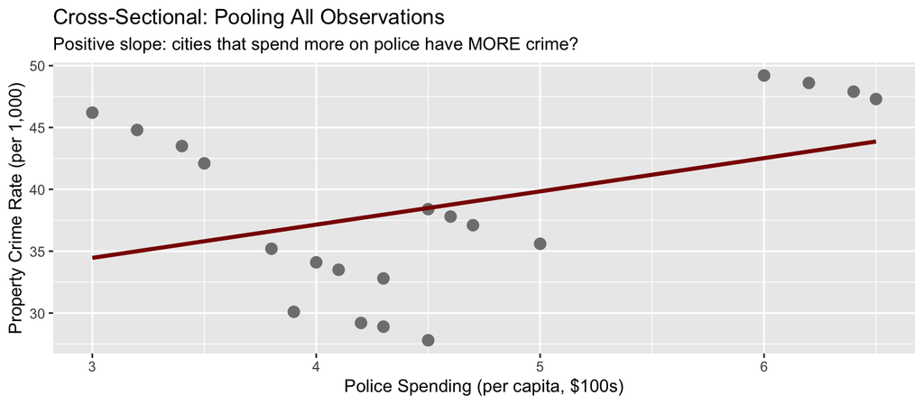

Figure 3

This is the **between** comparison — it looks like police spending *increases* crime.

## Now Layer in the Panel Structure

Same data, but now we connect observations **within** each city over time:

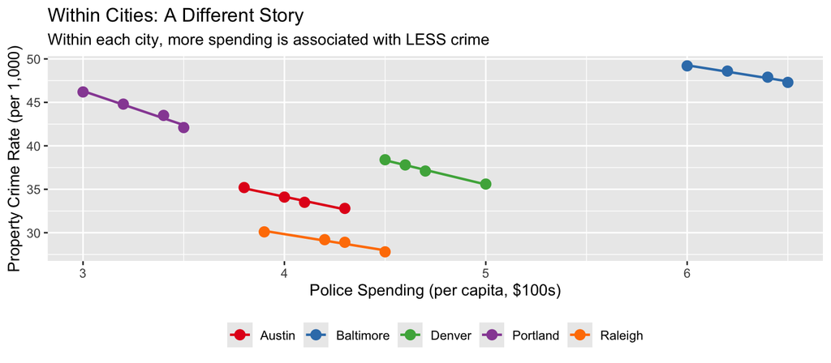

Figure 4

The **within-city** slopes tell the opposite story from the cross-sectional one!

## Why the Misleading Cross-Sectional Pattern?

Baltimore spends the most on police **and** has the highest crime.

But this doesn’t mean police spending *causes* crime. Cities with high crime invest more in policing precisely **because** they have high crime.

Those same cities also have persistent characteristics (poverty, density, historical disinvestment) that keep crime elevated regardless of spending.

The cross-sectional comparison conflates the **effect of police spending** with all the other ways these cities differ. We need fixed effects to separate them.

## Estimating with `feols()`

```r
fe_reg <- feols(property_crime ~ police_spend | city + year,
                data = city_panel)
summary(fe_reg)
```

```
OLS estimation, Dep. Var.: property_crime
Observations: 20
Fixed-effects: city: 5,  year: 4
Standard-errors: IID
             Estimate Std. Error  t value   Pr(>|t|)
police_spend -5.64412   0.554777 -10.1737 6.2226e-07 ***
---
Signif. codes:  0 '***' 0.001 '**' 0.01 '*' 0.05 '.' 0.1 ' ' 1
RMSE: 0.276304     Adj. R2: 0.997313
                 Within R2: 0.903933
```

After absorbing city and year fixed effects, more police spending is associated with **lower** crime — the opposite of what the cross-sectional data suggested.

## Extracting the Fixed Effects

- We can retrieve the estimated unit and time fixed effects with `fixef()`:

```r
fe_estimates <- fixef(fe_reg)
fe_estimates$city
```

```
   Austin Baltimore    Denver  Portland   Raleigh
 56.42819  83.33636  63.42187  62.30399  52.51591
```

```r
fe_estimates$year
```

```
     2017      2018      2019      2020
0.0000000 0.3759424 0.5932373 0.3528825
```

## What Do FE Control For?

**Unit FE** control for anything specific to a unit that is **constant over time**: geography, historical legacy, stable institutions, baseline demographics, measurement differences, culture.

**Time FE** control for anything that hits **all units equally** in a given period: macroeconomic shocks, national policy changes, seasonal patterns, technology trends.

**Neither** controls for factors that vary **both across units and over time** — for example, a city-specific economic boom or a policy change that only affects some cities. These are **unit-specific, time-varying confounders** and must be controlled for explicitly (or remain a source of potential bias).

## A Classification Exercise

For each confounder, is it absorbed by unit FE, time FE, or neither?

- A city’s geographic terrain?

**Unit FE** — constant across time for a given city

- National recession in 2020?

**Time FE** — hits all cities equally in that year

- City-specific economic boom in 2019?

**Neither** — varies across cities *and* over time

- Nationwide sentencing reform?

**Time FE** — affects all cities in the same period

- A city’s founding history?

**Unit FE** — permanent characteristic of that city

## Classification Exercise (cont.)

- A new mayor elected in one city in 2018?

**Neither** — specific to one city at one point in time

- A state’s distance from the border?

**Unit FE** — doesn’t change over time

- Nationwide COVID-19 lockdowns in 2020?

**Time FE** — common shock across all units

- A city-specific policing strategy introduced in 2019?

**Neither** — unit-specific and time-varying

The “neither” cases are **unit-specific, time-varying confounders**. These require explicit control variables.

## Adding Time-Varying Controls

- One way to address the fact that FEs don’y account for **unit-specific, time-varying confounders** is to directly control for them!
- Can do so by putting them in the RHS of our regression, like any other variable

$$y_{it} = \beta_1 x_{it} + \gamma z_{it} + a_i + \tau_t + \mu_{it}$$

- Of course, this requires that you are directly able to observe these variables, so only a partial solution

## Adding Time-Varying Controls

In `feols()`, time-varying controls go on the **left** side of `|`:

```r
city_panel <- city_panel |>
    mutate(unem_rate = c(3.1, 2.8, 2.9, 5.0, 5.8, 5.5, 5.3, 7.6,
                         3.0, 2.7, 2.8, 5.4, 3.8, 3.6, 3.9, 6.2,
                         3.4, 3.1, 3.0, 5.1))

fe_with_control <- feols(property_crime ~ police_spend + unem_rate | city + year,
                         data = city_panel)
```

```r
modelsummary(list("No Control" = fe_reg, "With Unemployment" = fe_with_control),
             gof_map = c("adj.r.squared"),
             add_rows = tribble(
                 ~term, ~`No Control`, ~`With Unemployment`,
                 "City FE", "Yes", "Yes",
                 "Year FE", "Yes", "Yes"
             ))
```

|  | No Control | With Unemployment |
| --- | --- | --- |
| police_spend | -5.644 | -5.395 |
|  | (0.555) | (0.624) |
| unem_rate |  | 0.644 |
|  |  | (0.713) |
| R2 Adj. | 0.997 | 0.997 |
| City FE | Yes | Yes |
| Year FE | Yes | Yes |

## When Are Fixed Effects Most Useful?

**Good fit for FE:**

- Genuine panel data (same units, multiple periods)
- Meaningful within-unit variation in $x$
- Time-invariant confounders are a primary concern
- Treatment effects are relatively immediate

**Less useful when:**

- Little within-unit variation (everyone’s $x$ is stable over time)
- Treatment effects take a long time to materialize
- Time-varying confounders are the main concern
- Very few time periods (less precise estimates)

## Summary

1. **Panel data**: same units observed over multiple time periods
2. The **within transformation** eliminates all time-invariant confounders by demeaning
3. **Unit FE** absorb permanent unit characteristics (observed and unobserved)
4. **Time FE** absorb shocks common to all units in a given period
5. In R: `feols(y ~ x | unit + time, data = mydata)`
6. Can add **time-varying controls** on the left side of `|`
7. **Cannot** include time-invariant variables — they’re collinear with unit FE

Fixed effects $\neq$ no OVB. Unit-specific, time-varying confounders can still bias results. But FE is a **major improvement** over cross-sectional analysis when time-invariant confounders are the primary concern.

## Try It Yourself

The `wagepan` dataset in `wooldridge` is a balanced panel of 545 men observed annually from 1980–1987.

```r
wage_data <- wooldridge::wagepan
```

**1.** How many workers? How many years? Confirm it’s balanced. (*Hint:* `n_distinct()`)

**2.** Using only 1987 data, estimate: $\ln(wage) = \beta_0 + \beta_1 \cdot union + \mu$. Interpret $\hat{\beta}_1$.

**3.** Now estimate with worker and year FE: `feols(lwage ~ union | nr + year)`. How does $\hat{\beta}_1$ change? Why?

**4.** Try adding `educ` as a control in the FE model. What happens? Why?